# RDA analysis

Sarah Mueller

2025 - final

## Set up data for RDA

For RDA analysis we need both the DNA methylation (dependent variable) and our covariates (explanatory variables).

```r
#sample names
sample_names <- read.table("/dss/dsshome1/lxc0B/ra52qed/gitlab/swallow.projects/scripts/0_sample.lists/sample.names.85.meth.sub.pop.txt", header=T)
#get explanatory variables set
info.climate <- read_xlsx("/dss/dsshome1/lxc0B/ra52qed/gitlab/swallow.projects/scripts/0_sample.lists/NCBI_info_updated_20220727_climate_data.xlsx", sheet = "Sheet7")
#add PC axes from genomic PCA
eigenvec <- "/dss/dsslegfs01/pr53da/pr53da-dss-0034/projects/2021_SwallowRRBS/5_WGS/1_Population_Structure/1_PCA/3_85.SM/HR.83.RDA.eigenvec"
pc.eigen <- read.table(eigenvec)
#read in general information table
info.full <- read_xlsx("/dss/dsshome1/lxc0B/ra52qed/gitlab/swallow.projects/scripts/0_sample.lists/NCBI_info_updated_20220727_climate_data.xlsx")
info.full <- full_join(info.full, info.climate, by= "sample_name")
info.full <- left_join(info.full, pc.eigen, by= c("sample_name" = "V1"))
#remove all individuals not used for this analysis
info.full=info.full %>%
  dplyr::slice(match(sample_names$V1, info.full$sample_name))
info.full$pop <- as.factor(sample_names$pop)
info.full$sub <- as.factor(sample_names$sub)
info.full$Latitude.approx <- as.numeric(info.full$Latitude.approx)
info.full$Longitude.approx <- as.numeric(info.full$Longitude.approx)

#remove 2 samples that had bad quality genomic data and therfoer no PCA data and 1 sample that was assigned incorrectly in genomic data
# Remove rows where info$sample_name matches the specified values
info.full <- info.full[!info.full$sample_name %in% c("IL_15_TV_X242015_BL_ADL_F", "IL_15_TV_X242048_BL_ADL_F", "EG_15_S_1611_BL_ADL_U"), ]

# Check the updated dataframe
head(info.full)
```

```
## # A tibble: 6 × 98
##   sample_id accession status sample_name Year  sample_title `contact:first_name`
##       <dbl> <chr>     <chr>  <chr>       <chr> <chr>        <chr>
## 1  25042295 SAMN2504… hup    CH_18_R_18… 2018  CH_18_R_18C… Sarah
## 2  25042296 SAMN2504… hup    CH_18_R_18… 2018  CH_18_R_18C… Sarah
## 3  25042297 SAMN2504… hup    CH_19_R_19… 2019  CH_19_R_19C… Sarah
## 4  25042298 SAMN2504… hup    CH_19_R_19… 2019  CH_19_R_19C… Sarah
## 5  25042299 SAMN2504… hup    CH_19_R_19… 2019  CH_19_R_19C… Sarah
## 6  25042300 SAMN2504… hup    CH_20_R_20… 2020  CH_20_R_20C… Sarah
## # ℹ 91 more variables: `contact:last_name` <chr>, `contact:email` <chr>,
## #   `owner:name` <chr>, taxonomy_id <dbl>, organism <chr>,
## #   publication_date <dttm>, package <chr>, bioproject <chr>, version <dbl>,
## #   ...17 <lgl>, strain <chr>, isolate <chr>, proportion_rustica <dbl>,
## #   breed <chr>, cultivar <chr>, ecotype <chr>, age.years <chr>,
## #   age.days.max <chr>, age.days.max.factor <chr>, age.days.min <chr>,
## #   dev_stage <chr>, sex <chr>, sex.rrbs <chr>, tissue <chr>, …
```

```r
# select all columns that will be used as possible variables...this is key to analysis and may change between iterations -------
# originally run with XXX environmental variable, longitude and latitude, PCA axis 1, and pop and subspecies AND sex. The following were kept for final analysis after forward testing permutations to determine significant variables
info <- info.full %>%
  dplyr::select("sex.rrbs", "tavg", "pres", "Latitude.approx", "Longitude.approx", "V3", "pop", "sub")%>%
  mutate_if(is.character,as.factor)
info$pres <- as.numeric(info$pres)


# summary to check if all are factor variables
summary(info)
```

```
##    sex.rrbs       tavg           pres       Latitude.approx Longitude.approx
##  female:38   Min.   :10.3   Min.   : 1.00   Min.   :31.41   Min.   :-76.501
##  male  :44   1st Qu.:17.3   1st Qu.: 9.00   1st Qu.:34.35   1st Qu.:  9.219
##              Median :19.9   Median :15.00   Median :52.02   Median : 33.662
##              Mean   :21.3   Mean   :14.65   Mean   :46.28   Mean   : 45.770
##              3rd Qu.:24.6   3rd Qu.:23.00   3rd Qu.:54.00   3rd Qu.:106.591
##              Max.   :29.0   Max.   :23.00   Max.   :61.49   Max.   :108.806
##        V3            pop     sub
##  Min.   :-0.208007   CN:12   E : 7
##  1st Qu.:-0.065448   EG: 7   G :12
##  Median : 0.049420   EU:27   R :39
##  Mean   : 0.001506   IL: 6   S : 7
##  3rd Qu.: 0.057175   RU:23   T :11
##  Max.   : 0.220062   US: 7   TV: 6
```

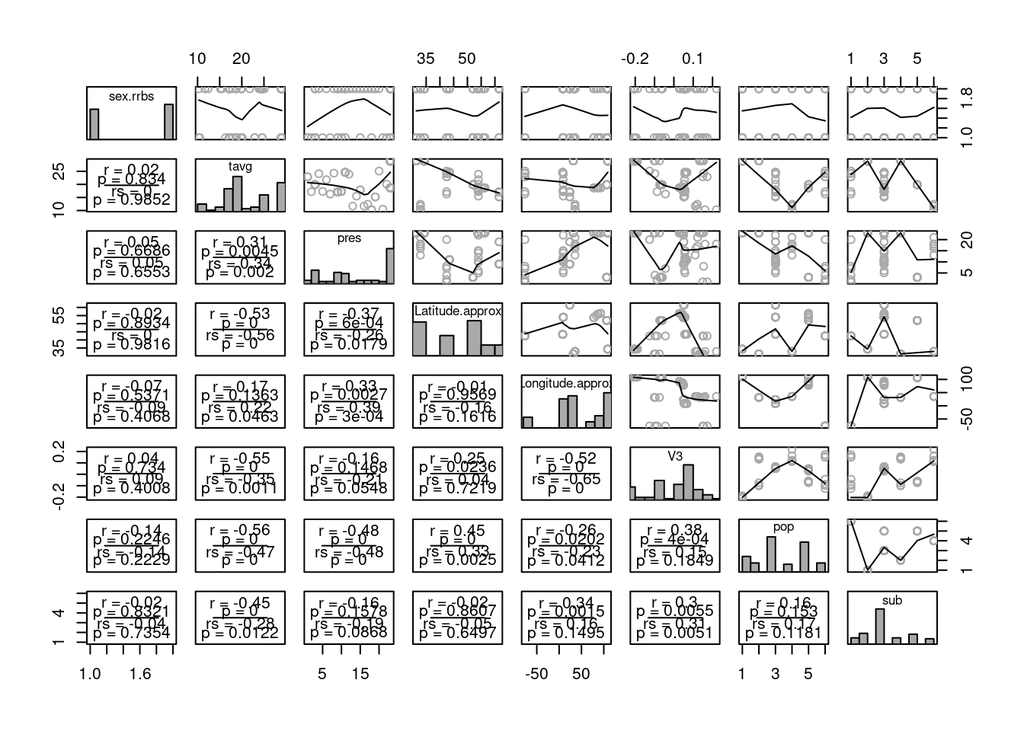

```r
# define color palette -----------------
color_sub <- c(  "#08d124", #E
                "#07038a", #G
                "#d30000", #R
                #"#9716a8", #RG
                #"#FFA500", #RT
                "#be6400", #S
                "#622a0f", #TV
                "#f4d000", #T
                "grey") #NA/unknown



# visualize using pairs ------------------
pairscor.fnc(info)
```

## Load in methylation data

Here, we can also specify a subset of samples if there are individuals we want to exclude

##Explore different distance indices

##Create a model using all variables

We know from previous analysis on a subset of 17 known age and sex individuals that sex has a clear influence on methylation sites (see results of age and sex evaluation 3.1 and 3.2). Additionally from the RDA analysis on 168 individuals where sex was a significant variable. Therefore, we can use a partial RDA analysis. This partial RDA uses a matrix Y, explained by a matrix variables X, in the presence of co-variable(s) W. This analysis allows to display the patterns of the response data (Y) uniquely explained by a linear model of the explanatory variables (X) when the effect of other covariates (W) is held constant (Borcard, Gillet, and Legendre 2011).

```
##     sex.rrbsmale             tavg             pres  Latitude.approx
##         1.063709         4.118921         2.832434         5.884221
## Longitude.approx               V3            popEG            popEU
##        19.495849         2.225345         7.498026        15.981129
##            popIL            popRU            popUS             subG
##         6.924060         5.036555        19.138512               NA
##             subR             subS             subT            subTV
##         5.952298               NA               NA               NA
```

```
## [1] "Adjusted R² of the full model: 0.0432921971648903"
```

```
## Testing variable 1
## Testing variable 2
## Testing variable 3
## Testing variable 4
## Testing variable 5
## Testing variable 6
## Testing variable 7
## Testing variable 8
```

```
##          variables order         R2      R2Cum   AdjR2Cum        F pval
## 1         sex.rrbs     1 0.02334519 0.02334519 0.01113701 1.912258 0.01
## 2               V3     6 0.01978126 0.04312646 0.01890181 1.633152 0.01
## 3              pop     7 0.01782896 0.06095542 0.02483832 1.480930 0.01
## 4 Longitude.approx     5 0.01591332 0.07686875 0.02891388 1.327358 0.01
## 5  Latitude.approx     4 0.01554959 0.09241834 0.03270902 1.302108 0.01
## 6             tavg     2 0.01410763 0.10652597 0.03504805 1.184223 0.01
## 7              sub     8 0.01414086 0.12066683 0.03748666 1.190019 0.01
## 8             pres     3 0.01361716 0.13428399 0.03941101 1.148244 0.04
```

```
## [1] "Adjusted R² of the parsimonious model: 0.0394110065666349"
```

```r
# Partial RDA --------------

##A partial rda which looks at possible explanatory variables while holding the variation from some others constant
partial_rda <- dbrda(prop_nohyb ~ tavg + pres + Latitude.approx + Longitude.approx + V3 + pop + sub + Condition(sex.rrbs), reduced_data)

#conditioned means explained by conditions, constrained explained by explanatory variables, unconstrained is unidentified variance
summary(partial_rda)
```

```
##
## Call:
## dbrda(formula = prop_nohyb ~ tavg + pres + Latitude.approx +      Longitude.approx + V3 + pop + sub + Condition(sex.rrbs),      data = reduced_data)
##
## Partitioning of squared Euclidean distance:
##                Inertia Proportion
## Total         0.387310    1.00000
## Conditioned   0.009042    0.02335
## Constrained   0.042968    0.11094
## Unconstrained 0.335301    0.86572
##
## Eigenvalues, and their contribution to the squared Euclidean distance
## after removing the contribution of conditiniong variables
##
## Importance of components:
##                         dbRDA1   dbRDA2   dbRDA3   dbRDA4   dbRDA5   dbRDA6
## Eigenvalue            0.008608 0.007829 0.006687 0.005215 0.005118 0.004837
## Proportion Explained  0.022756 0.020697 0.017678 0.013787 0.013530 0.012788
## Cumulative Proportion 0.022756 0.043453 0.061131 0.074918 0.088448 0.101236
##                         dbRDA7    MDS1     MDS2     MDS3    MDS4     MDS5
## Eigenvalue            0.004673 0.01139 0.007575 0.007164 0.00705 0.006294
## Proportion Explained  0.012354 0.03012 0.020026 0.018939 0.01864 0.016640
## Cumulative Proportion 0.113591 0.14371 0.163735 0.182674 0.20131 0.217950
##                           MDS6     MDS7     MDS8     MDS9    MDS10    MDS11
## Eigenvalue            0.006184 0.006032 0.005765 0.005678 0.005609 0.005554
## Proportion Explained  0.016347 0.015946 0.015240 0.015011 0.014829 0.014683
## Cumulative Proportion 0.234297 0.250243 0.265483 0.280494 0.295323 0.310006
##                          MDS12   MDS13    MDS14    MDS15    MDS16    MDS17
## Eigenvalue            0.005437 0.00539 0.005323 0.005272 0.005191 0.005179
## Proportion Explained  0.014373 0.01425 0.014071 0.013937 0.013724 0.013691
## Cumulative Proportion 0.324379 0.33863 0.352699 0.366636 0.380360 0.394051
##                          MDS18    MDS19    MDS20    MDS21    MDS22    MDS23
## Eigenvalue            0.005113 0.005052 0.005015 0.004947 0.004913 0.004853
## Proportion Explained  0.013517 0.013356 0.013258 0.013078 0.012988 0.012828
## Cumulative Proportion 0.407568 0.420924 0.434182 0.447260 0.460247 0.473076
##                          MDS24    MDS25    MDS26    MDS27    MDS28    MDS29
## Eigenvalue            0.004745 0.004716 0.004675 0.004663 0.004596 0.004583
## Proportion Explained  0.012543 0.012466 0.012360 0.012328 0.012150 0.012115
## Cumulative Proportion 0.485618 0.498085 0.510445 0.522773 0.534923 0.547038
##                          MDS30    MDS31    MDS32    MDS33    MDS34    MDS35
```

[output cut: 27 more lines]

```
##                          MDS72    MDS73
## Eigenvalue            0.003157 0.003094
## Proportion Explained  0.008347 0.008179
## Cumulative Proportion 0.991821 1.000000
##
## Accumulated constrained eigenvalues
## Importance of components:
##                         dbRDA1   dbRDA2   dbRDA3   dbRDA4   dbRDA5   dbRDA6
## Eigenvalue            0.008608 0.007829 0.006687 0.005215 0.005118 0.004837
## Proportion Explained  0.200334 0.182204 0.155631 0.121375 0.119111 0.112582
## Cumulative Proportion 0.200334 0.382538 0.538170 0.659545 0.778655 0.891237
##                         dbRDA7
## Eigenvalue            0.004673
## Proportion Explained  0.108763
## Cumulative Proportion 1.000000
```

```r
#However, this has not been corrected and lowers significantly when corrected
global_r2 <- RsquareAdj(partial_rda)


#Rsquared
global_r2 <- round(RsquareAdj(partial_rda)$adj.r.squared, digits=4)

#1. global sig
anova_global <- anova(partial_rda)
p.val <- anova_global$`Pr(>F)`
p.val
```

```
## [1] 0.001    NA
```

```r
##2. Axis significance
anova.cca(partial_rda,  by="axis")
```

```
## Permutation test for dbrda under reduced model
## Forward tests for axes
## Permutation: free
## Number of permutations: 999
##
## Model: dbrda(formula = prop_nohyb ~ tavg + pres + Latitude.approx + Longitude.approx + V3 + pop + sub + Condition(sex.rrbs), data = reduced_data)
##          Df SumOfSqs      F Pr(>F)
## dbRDA1    1  0.00861 1.8741  0.001 ***
## dbRDA2    1  0.00783 1.7278  0.001 ***
## dbRDA3    1  0.00669 1.4958  0.001 ***
## dbRDA4    1  0.00522 1.1821  0.102
## dbRDA5    1  0.00512 1.1753  0.102
## dbRDA6    1  0.00484 1.1253  0.102
## dbRDA7    1  0.00467 1.1011  0.102
## Residual 73  0.33530
## ---
## Signif. codes:  0 '***' 0.001 '**' 0.01 '*' 0.05 '.' 0.1 ' ' 1
```

```r
#3. Term significance
anova.cca(partial_rda,  by="terms")
```

```
## Permutation test for dbrda under reduced model
## Terms added sequentially (first to last)
## Permutation: free
## Number of permutations: 999
##
## Model: dbrda(formula = prop_nohyb ~ tavg + pres + Latitude.approx + Longitude.approx + V3 + pop + sub + Condition(sex.rrbs), data = reduced_data)
##                  Df SumOfSqs      F Pr(>F)
## tavg              1  0.00675 1.4690  0.001 ***
## pres              1  0.00535 1.1657  0.005 **
## Latitude.approx   1  0.00553 1.2043  0.006 **
## Longitude.approx  1  0.00685 1.4913  0.001 ***
## V3                1  0.00633 1.3776  0.001 ***
## pop               1  0.00629 1.3689  0.001 ***
## sub               1  0.00587 1.2779  0.002 **
## Residual         73  0.33530
## ---
## Signif. codes:  0 '***' 0.001 '**' 0.01 '*' 0.05 '.' 0.1 ' ' 1
```

```r
RsquareAdj(partial_rda)
```

```
## $r.squared
## [1] 0.1109388
##
## $adj.r.squared
## [1] 0.028274
```

```r
# Partial RDA --------------

##A partial rda which looks at possible explanatory variables while holding the variation from some others constant
partial_rda <- dbrda(prop_nohyb ~ V3 + pop + Longitude.approx + tavg + sub + Latitude.approx  + pres + Condition(sex.rrbs), reduced_data)

#conditioned means explained by conditions, constrained explained by explanatory variables, unconstrained is unidentified variance
summary(partial_rda)
```

```
##
## Call:
## dbrda(formula = prop_nohyb ~ V3 + pop + Longitude.approx + tavg +      sub + Latitude.approx + pres + Condition(sex.rrbs), data = reduced_data)
##
## Partitioning of squared Euclidean distance:
##                Inertia Proportion
## Total         0.387310    1.00000
## Conditioned   0.009042    0.02335
## Constrained   0.042968    0.11094
## Unconstrained 0.335301    0.86572
##
## Eigenvalues, and their contribution to the squared Euclidean distance
## after removing the contribution of conditiniong variables
##
## Importance of components:
##                         dbRDA1   dbRDA2   dbRDA3   dbRDA4   dbRDA5   dbRDA6
## Eigenvalue            0.008608 0.007829 0.006687 0.005215 0.005118 0.004837
## Proportion Explained  0.022756 0.020697 0.017678 0.013787 0.013530 0.012788
## Cumulative Proportion 0.022756 0.043453 0.061131 0.074918 0.088448 0.101236
##                         dbRDA7    MDS1     MDS2     MDS3    MDS4     MDS5
## Eigenvalue            0.004673 0.01139 0.007575 0.007164 0.00705 0.006294
## Proportion Explained  0.012354 0.03012 0.020026 0.018939 0.01864 0.016640
## Cumulative Proportion 0.113591 0.14371 0.163735 0.182674 0.20131 0.217950
##                           MDS6     MDS7     MDS8     MDS9    MDS10    MDS11
## Eigenvalue            0.006184 0.006032 0.005765 0.005678 0.005609 0.005554
## Proportion Explained  0.016347 0.015946 0.015240 0.015011 0.014829 0.014683
## Cumulative Proportion 0.234297 0.250243 0.265483 0.280494 0.295323 0.310006
##                          MDS12   MDS13    MDS14    MDS15    MDS16    MDS17
## Eigenvalue            0.005437 0.00539 0.005323 0.005272 0.005191 0.005179
## Proportion Explained  0.014373 0.01425 0.014071 0.013937 0.013724 0.013691
## Cumulative Proportion 0.324379 0.33863 0.352699 0.366636 0.380360 0.394051
##                          MDS18    MDS19    MDS20    MDS21    MDS22    MDS23
## Eigenvalue            0.005113 0.005052 0.005015 0.004947 0.004913 0.004853
## Proportion Explained  0.013517 0.013356 0.013258 0.013078 0.012988 0.012828
## Cumulative Proportion 0.407568 0.420924 0.434182 0.447260 0.460247 0.473076
##                          MDS24    MDS25    MDS26    MDS27    MDS28    MDS29
## Eigenvalue            0.004745 0.004716 0.004675 0.004663 0.004596 0.004583
## Proportion Explained  0.012543 0.012466 0.012360 0.012328 0.012150 0.012115
## Cumulative Proportion 0.485618 0.498085 0.510445 0.522773 0.534923 0.547038
##                          MDS30    MDS31    MDS32    MDS33    MDS34    MDS35
```

[output cut: 27 more lines]

```
##                          MDS72    MDS73
## Eigenvalue            0.003157 0.003094
## Proportion Explained  0.008347 0.008179
## Cumulative Proportion 0.991821 1.000000
##
## Accumulated constrained eigenvalues
## Importance of components:
##                         dbRDA1   dbRDA2   dbRDA3   dbRDA4   dbRDA5   dbRDA6
## Eigenvalue            0.008608 0.007829 0.006687 0.005215 0.005118 0.004837
## Proportion Explained  0.200334 0.182204 0.155631 0.121375 0.119111 0.112582
## Cumulative Proportion 0.200334 0.382538 0.538170 0.659545 0.778655 0.891237
##                         dbRDA7
## Eigenvalue            0.004673
## Proportion Explained  0.108763
## Cumulative Proportion 1.000000
```

```r
#However, this has not been corrected and lowers significantly when corrected
global_r2 <- RsquareAdj(partial_rda)


#Rsquared
global_r2 <- round(RsquareAdj(partial_rda)$adj.r.squared, digits=4)

#1. global sig
anova_global <- anova(partial_rda)
p.val <- anova_global$`Pr(>F)`
p.val
```

```
## [1] 0.001    NA
```

```r
##2. Axis significance
anova.cca(partial_rda,  by="axis")
```

```
## Permutation test for dbrda under reduced model
## Forward tests for axes
## Permutation: free
## Number of permutations: 999
##
## Model: dbrda(formula = prop_nohyb ~ V3 + pop + Longitude.approx + tavg + sub + Latitude.approx + pres + Condition(sex.rrbs), data = reduced_data)
##          Df SumOfSqs      F Pr(>F)
## dbRDA1    1  0.00861 1.8741  0.001 ***
## dbRDA2    1  0.00783 1.7278  0.001 ***
## dbRDA3    1  0.00669 1.4958  0.001 ***
## dbRDA4    1  0.00522 1.1821  0.093 .
## dbRDA5    1  0.00512 1.1753  0.093 .
## dbRDA6    1  0.00484 1.1253  0.093 .
## dbRDA7    1  0.00467 1.1011  0.093 .
## Residual 73  0.33530
## ---
## Signif. codes:  0 '***' 0.001 '**' 0.01 '*' 0.05 '.' 0.1 ' ' 1
```

```r
#3. Term significance
anova.cca(partial_rda,  by="terms")
```

```
## Permutation test for dbrda under reduced model
## Terms added sequentially (first to last)
## Permutation: free
## Number of permutations: 999
##
## Model: dbrda(formula = prop_nohyb ~ V3 + pop + Longitude.approx + tavg + sub + Latitude.approx + pres + Condition(sex.rrbs), data = reduced_data)
##                  Df SumOfSqs      F Pr(>F)
## V3                1  0.00766 1.6680  0.001 ***
## pop               1  0.00691 1.5034  0.001 ***
## Longitude.approx  1  0.00616 1.3419  0.001 ***
## tavg              1  0.00583 1.2685  0.002 **
## sub               1  0.00561 1.2224  0.006 **
## Latitude.approx   1  0.00552 1.2023  0.004 **
## pres              1  0.00527 1.1482  0.011 *
## Residual         73  0.33530
## ---
## Signif. codes:  0 '***' 0.001 '**' 0.01 '*' 0.05 '.' 0.1 ' ' 1
```

```r
RsquareAdj(partial_rda)
```

```
## $r.squared
## [1] 0.1109388
##
## $adj.r.squared
## [1] 0.028274
```

```r
#pull R2 values for each component
# Total inertia (total variance)
total_inertia <- sum(partial_rda$CCA$eig) + sum(partial_rda$CA$eig)

# Conditioned variance (variance explained by covariates)
conditioned_inertia <- sum(partial_rda$pCCA$tot.chi)

# Constrained variance (variance explained by explanatory variables)
constrained_inertia <- sum(partial_rda$CCA$eig)

# Residual (unconstrained) variance
residual_inertia <- sum(partial_rda$CA$eig)

# Proportion of variance explained
conditioned_R2 <- conditioned_inertia / total_inertia
constrained_R2 <- constrained_inertia / total_inertia
residual_R2 <- residual_inertia / total_inertia

# Print results
cat("Conditioned R²:", conditioned_R2, "\n")
```

```
## Conditioned R²: 0.02390322
```

```r
cat("Constrained R²:", constrained_R2, "\n")
```

```
## Constrained R²: 0.1135906
```

```r
cat("Residual R²:", residual_R2, "\n")
```

```
## Residual R²: 0.8864094
```

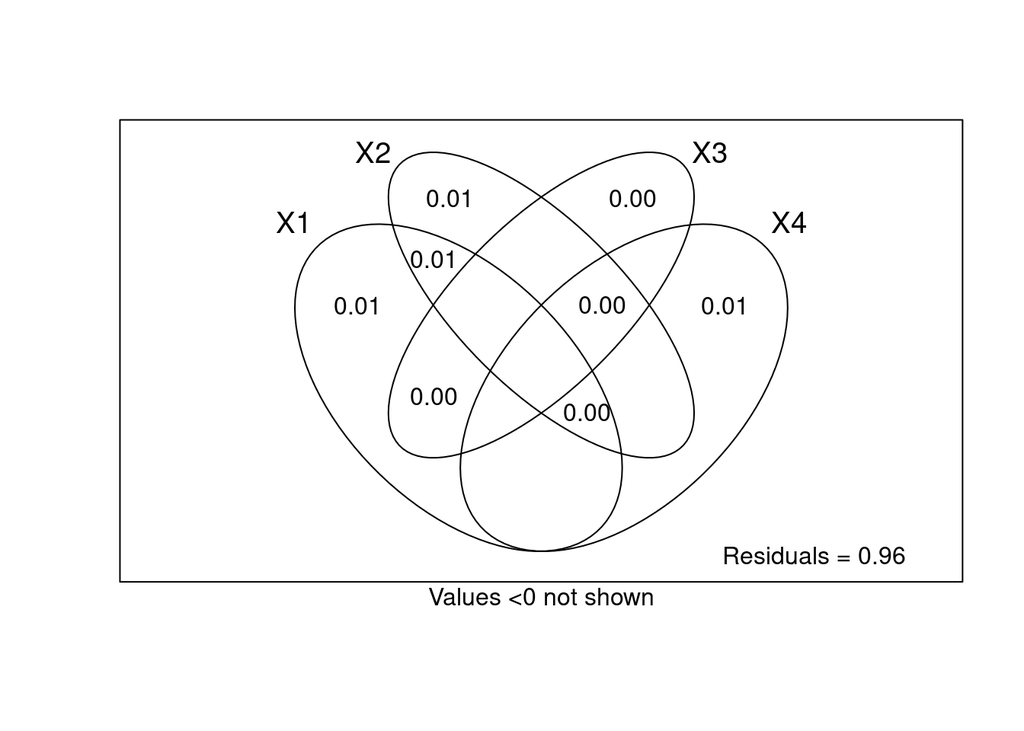

```r
#Variance Paritioning

#separate sex
genetic <- reduced_data[,c(2:3,6)]
spatial <- reduced_data[,c(4,7)]
env <- reduced_data[,c(5,8)]
covar <- reduced_data[,1]

vp <- varpart(prop_nohyb, genetic, spatial, env, covar)


plot(vp)
```

## Assign plotting functions

Here, we can use a function that plots the PCA so we can plot several at once

```r
# Sites (individual scores)
prda.sites <- scores(partial_rda, display = "sites")
# Constraints (canonical axes)
prda.constraints <- scores(partial_rda, display = "lc")
# Biplot (explanatory variables)
prda.biplot <- scores(partial_rda, display = "bp")

#put as dataframes for easy working in ggplot
prda.sites <- as.data.frame(prda.sites)
prda.biplot <- as.data.frame(prda.biplot)

# Proportion of variance explained by each constrained axis
partial_rda$CCA$eig           # eigenvalues for constrained axes
```

```
##      dbRDA1      dbRDA2      dbRDA3      dbRDA4      dbRDA5      dbRDA6
## 0.008607892 0.007828905 0.006687134 0.005215210 0.005117925 0.004837393
##      dbRDA7
## 0.004673282
```

```r
partial_rda$CCA$eig[1]        # first constrained eigenvalue
```

```
##      dbRDA1
## 0.008607892
```

```r
# Total constrained variance
sum(partial_rda$CCA$eig)      # sum of all constrained eigenvalues
```

```
## [1] 0.04296774
```

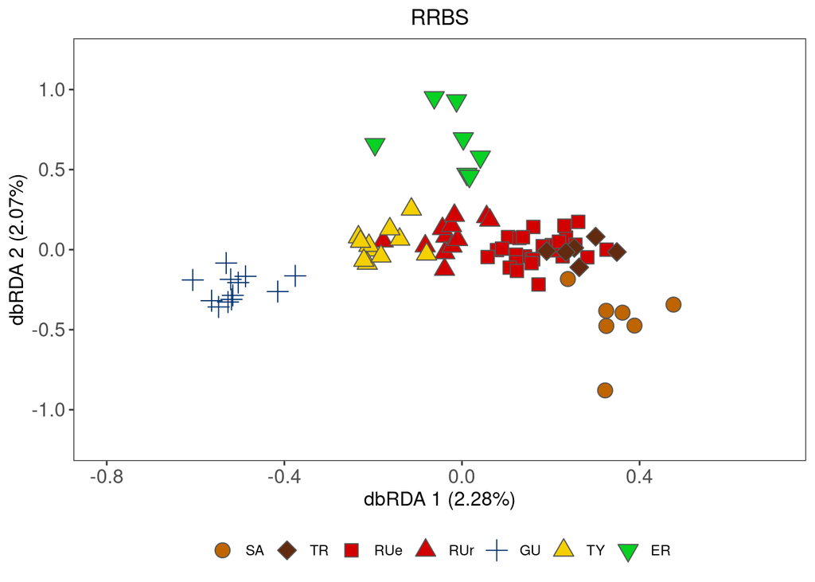

```r
#Calculate total variance
total_var <- sum(partial_rda$CCA$eig) + sum(partial_rda$CA$eig)

# % of overall variance explained by first constrained axis
pct_axis1 <- 100 * partial_rda$CCA$eig[1] / total_var
pct_axis2 <- 100 * partial_rda$CCA$eig[2] / total_var

#Fix sub and pop to plot correctly
info.full <- info.full %>%
  mutate(sub.pop = case_when(
    sub == "G" ~ "GU",
    sub == "T" ~ "TY",
    sub == "TV" ~ "TR",
    sub == "E" ~ "ER",
    sub == "S" ~ "SA",
    sub == "R" & pop == "EU" ~ "RUe",
    sub == "R" & pop == "RU" ~ "RUr",
    TRUE ~ NA_character_  # fallback for any unmatched rows
  ))

# Define the order
subpop_levels <- c("SA", "TR", "RUe", "RUr", "GU", "TY", "ER")

# Convert sub.pop to factor with correct order
info.full <- info.full %>%
  mutate(sub.pop = factor(sub.pop, levels = subpop_levels))

# Make sure sub.pop is a factor with the desired legend order
info.full$sub.pop <- factor(info.full$sub.pop,
                            levels = c("SA", "TR", "RUe", "RUr", "GU", "TY", "ER"))

p <- ggplot() +
  geom_point(data = prda.sites,
             aes(x = dbRDA1, y = -dbRDA2,
                 shape = info.full$sub.pop,
                 fill = info.full$sub.pop,
                 color = info.full$sub.pop),
             size = 4) +
  geom_segment(data = prda.biplot,
               aes(x = 0, y = 0, xend = dbRDA1*7, yend = dbRDA2*7),
               arrow = arrow(angle=22.5, length = unit(0.35,"cm"),
                             type = "closed"),
               linetype=1, size=0.6, colour = "grey77") +
  geom_text_repel(data = prda.biplot,
                  aes(x = dbRDA1*7, y = dbRDA2*7, label = rownames(prda.biplot))) +
  scale_shape_manual(values = c("SA"=21, "TR"=23, "RUe"=22,
                                "RUr"=24, "GU"=3, "TY"=24, "ER"=25)) +
  scale_fill_manual(values = c("SA"="#be6400", "TR"="#622a0f", "RUe"="#d30000",
                               "RUr"="#d30000", "GU"="#07038a", "TY"="#f4d000", "ER"="#08d124")) +
  scale_color_manual(values = c("SA"="grey33", "TR"="grey33", "RUe"="grey33",
                                "RUr"="grey33", "GU"="#00316e", "TY"="grey33", "ER"="grey33")) +
  labs(shape="Population", fill="Population", color="Population") +
  labs(
    x = paste0("dbRDA 1 (", round(pct_axis1, 2), "%)"),
    y = paste0("dbRDA 2 (", round(pct_axis2, 2), "%)")
  )+
  guides(
    shape = guide_legend(nrow = 1, byrow = TRUE, override.aes = list(size = 4)),
    fill = guide_legend(nrow = 1, byrow = TRUE, override.aes = list(size = 4)),
    color = guide_legend(nrow = 1, byrow = TRUE, override.aes = list(size = 4))
  ) +
  theme_bw() +
  theme(
    plot.title = element_text(hjust = 0.5),
    panel.grid = element_blank(),
    legend.title = element_blank(),
    legend.position = "bottom",
    legend.box = "horizontal",
    axis.text.x = element_text(size = 12),   # x-axis tick labels
    axis.title.x = element_text(size = 12),  # x-axis title
    axis.text.y = element_text(size = 12),
    axis.title.y = element_text(size = 12)
  ) +
  xlim(-.8, .7) + ylim(-1.2, 1.2) +
  ggtitle("RRBS")
p
```

save image

```r
ggsave("/dss/dsslegfs01/pr53da/pr53da-dss-0034/projects/2021_SwallowRRBS/1_Population_Structure/2_RDA/Supp.Fig.island.RDA.85.20miss.png", plot = p, width = 5, height = 5.1, units = "in", dpi = 500)
```